# Relatedness & Heterozygosity - Model 1 (cluster)

Emma Ochsner

This notebook helps looking at the rates of decline in heterozygosity and increase in relatedness for the different mateChoice models.

I have simulated the data on the server and want to analyze it now. For this I’ve created a folder, which is connected to the output folder on the server of this model. In this way, i don’t have to load all the data on my computer.

The size of the starting population is 1000 individuals or 16 individuals, which have different genomes and they mate for 100 generations - some modifications in the code have to be done depending on the population size

```r
#This is for the output on the server for the model with 16 individuals
setwd("/tmp/server_data_rel_het_16")
#This is for the output on the server for the model with 1000 individuals
#setwd("/tmp/server_data_rel_het_1000")

rm(list=ls(all=TRUE)) #clear R environment

files_nrnr <- list.files(pattern = "_heterozygosity_nrnr_") #list all files with this pattern in the name
length(files_nrnr) #check if it got all the files
```

```
[1] 1000
```

```r
#This will create a list of data frames, where every element is a replicate. Each replicate will have the column: Generation, Relatedness and heterozygosity.
rep_data_nrnr <- lapply(files_nrnr, function(f) {
  read.table(f, col.names = c("generation", "relatedness", "heterozygosity"))
})
#lapply is a command which applies a function to all the elements in a vector - So here it names the columns of every file, stored in files_nrnr

# Assume all replicates have the same generations - define the generations for later plot them
generations <- rep_data_nrnr[[1]]$generation

# Extract relatedness into a new matrix: each column = one replicate
rel_matrix_nrnr <- sapply(rep_data_nrnr, function(df) df$relatedness)
#Specifically this tells R: Go through every element "df" in the list rep_data_nrnr, and extract the relatedness column.

# Compute mean relatedness per generation
rel_mean_nrnr <- rowMeans(rel_matrix_nrnr)

#Now do the same for heterozygosity
het_matrix_nrnr <- sapply(rep_data_nrnr, function(df) df$heterozygosity) #create a new matrix for all heterozygosity values
het_mean_nrnr <- rowMeans(het_matrix_nrnr)

#And now again all this for the data of the model which has non-random mating selecting for relatedness (nrr)

files_nrr <- list.files(pattern = "_heterozygosity_nrr_")
length(files_nrr)
```

```
[1] 1000
```

```r
rep_data_nrr <- lapply(files_nrr, function(f) {
  read.table(f, col.names = c("generation", "relatedness", "heterozygosity"))
})

rel_matrix_nrr <- sapply(rep_data_nrr, function(df) df$relatedness)
rel_mean_nrr <- rowMeans(rel_matrix_nrr)

het_matrix_nrr <- sapply(rep_data_nrr, function(df) df$heterozygosity)
het_mean_nrr <- rowMeans(het_matrix_nrr)


#And now again all this for the data of the model which has random mating (r)

files_r <- list.files(pattern = "_heterozygosity_r_")
length(files_r)
```

```
[1] 1000
```

```r
rep_data_r <- lapply(files_r, function(f) {
  read.table(f, col.names = c("generation", "relatedness", "heterozygosity"))
}) #lapply: apply a function over a list

rel_matrix_r <- sapply(rep_data_r, function(df) df$relatedness)
rel_mean_r <- rowMeans(rel_matrix_r)

het_matrix_r <- sapply(rep_data_r, function(df) df$heterozygosity)
het_mean_r <- rowMeans(het_matrix_r)
```

Now i have sorted my data and can combine them into 2 graphs. I do one graph which shows the relatedness over the generations in the 3 different models and one for the heterozygosity values.

```r
par(mfrow = c(1, 2)) #To have 2 plots shown at once
par(mfrow = c(1, 2), oma = c(2, 0, 1, 0))  # oma = outer margin area (bottom, left, top, right), leaves space for a title and some space at the bottom to add a legend outside of the plots.

par(mgp = c(1.8, 0.7, 0)) #This is to decrease the distance of the axis labels to the axis.

par(cex.lab = 0.8, cex.axis = 0.7, cex.main = 1) #this helps me rescaling the size of the labels

# Combine both matrices into one big matrix to find global max and min
max_rel <- max(rel_matrix_nrnr, rel_matrix_nrr, rel_matrix_r)
min_rel <- min(rel_matrix_nrnr, rel_matrix_nrr, rel_matrix_r)

x_vals <- 1:100

# Model nrnr: light blue points
#Here i don't have to transpose the data, since each column is a separate data series - as expected by the matplot command
matplot(x_vals, rel_matrix_nrnr, type = "p", pch = 16, cex = 0.3,
        col = adjustcolor("#54BFB7FF", alpha.f = 0.01),
        xlab = "Generation", ylab = "Relatedness",
        ylim = c(min_rel, max_rel))


# Model nrr: light brown points
matpoints(x_vals, rel_matrix_nrr, pch = 16, cex = 0.3, col = adjustcolor("#894B33FF", alpha.f = 0.01)) #adding points to the existing plot from above
```

```r
# Model r: light orange points
matpoints(x_vals, rel_matrix_r, pch = 16, cex = 0.2, col = adjustcolor("tan1", alpha.f = 0.01)) #again

# === adding Mean relatedness lines to the plot ===
lines(x_vals, rel_mean_nrnr, col = "#54BFB7FF", lwd = 2.5)
```

```r
lines(x_vals, rel_mean_nrr, col = "#894B33FF", lwd = 2)
lines(x_vals, rel_mean_r, col = "tan1", lwd = 2, lty = 1) #When running with 1000 individuals: dashed oragnge line (lty = 4) to show the blue one behind it  - when having 16: lty = 1
```

```r
text(x = par("usr")[1], y = par("usr")[4], labels = "A", font = 2, cex = 1.1, adj = c(-0.5, 1.5))
#par("usr") gives the plot coordinates (so top left corner of the graph - 1 & 4), then labels = ... gives the plot a label, and then make it bold and larger, and adj places the label correctly

#And now the exactly same but for the heterozygosity values

# Combine both matrices into one big matrix to find global max and min
max_het <- max(het_matrix_nrnr, het_matrix_nrr, het_matrix_r)
min_het <- min(het_matrix_nrnr, het_matrix_nrr, het_matrix_r)

# Model nrnr: light blue points
matplot(x_vals, het_matrix_nrnr, type = "p", pch = 16, cex = 0.3,
        col = adjustcolor("#54BFB7FF", alpha.f = 0.01),
        xlab = "Generation", ylab = "Heterozygosity",
        ylim = c(min_het, max_het + 0.0003))  # add 0.0003 such that the "B" is not above the data
```

```r
# Model nrr: light brown points
matpoints(x_vals, het_matrix_nrr, pch = 16, cex = 0.3, col = adjustcolor("#894B33FF", alpha.f = 0.01)) #add points

# Model r: light orange points
matpoints(x_vals, het_matrix_r, pch = 16, cex = 0.2, col = adjustcolor("tan1", alpha.f = 0.01)) #add points
```

```r
# add Mean relatedness lines to the plot - (change lwd of blue line to 2.5 when plotting data of the 1000 individuals, to better visualize it)
lines(x_vals, het_mean_nrnr, col = "#54BFB7FF", lwd = 2)
lines(x_vals, het_mean_nrr, col = "#894B33FF", lwd = 2)
```

```r
lines(x_vals, het_mean_r, col = "tan1", lwd = 2, lty = 1) #when running with 1000 individuals: dashed orange line to visualize the blue one behind (lty = 4), otherwise lty = 1

mtext("Relatedness and Heterozygosity over Time \n(16 individuals)", side = 3, line = -2, outer = TRUE, cex = 1.2, font = 2) #creates a shared title
```

```r
#mtext("(1000 individuals)", side = 3, line = -2, outer = TRUE, cex = 1.2, font = 2) #for 1000 individuals
#change title to 16/1000 indivuals depending on the data - Or take the second line for 1000 individuals
#font = 2 makes the main bold
#\n makes a new line within the title


par(xpd = NA) #Allows drawing outside of the plot - this is for the legend
#now add a legend
legend("bottom", inset = c(0, -0.6), horiz = FALSE,
       legend = c("not-random not-related", "not-random related", "random"),
       col = c("#54BFB7FF", "#894B33FF", "tan1"),
       lwd = 2, lty = c(1, 1, 1), bty = "n", cex = 0.6)
```

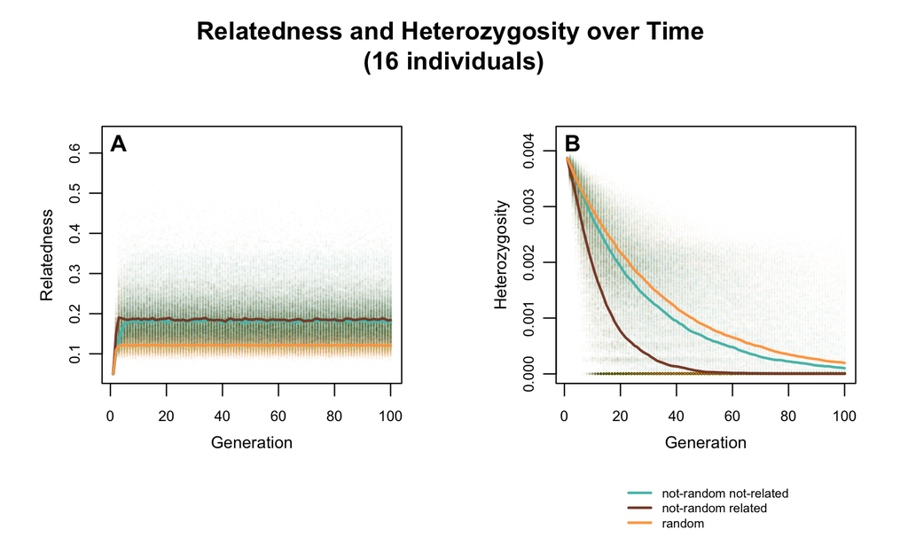

```r
#inset: Pushes it down below the plot
#when 1000 individuals change to lty = c(1, 1, 4) - for 16 individuals c(1, 1, 1)

text(x = par("usr")[1], y = par("usr")[4], labels = "B", font = 2, cex = 1.1, adj = c(-0.5, 1.5))
```

```r
NA
NA
```

And again the same graphs but without the points for better visualization…

```r
par(mfrow = c(1, 2)) #To have 2 plots shown at once
par(mfrow = c(1, 2), oma = c(2, 0, 1, 0))  # oma = outer margin area (bottom, left, top, right), leaves space for a title and some space at the bottom to add a legend outside of the plots.

par(mgp = c(1.8, 0.7, 0)) #This is to decrease the distance of the axis labels to the axis.

par(cex.lab = 0.8, cex.axis = 0.7, cex.main = 1) #this helps me rescaling the size of the labels

# Combine both matrices into one big matrix to find global max and min
max_rel <- max(rel_matrix_nrnr, rel_matrix_nrr, rel_matrix_r)
min_rel <- min(rel_matrix_nrnr, rel_matrix_nrr, rel_matrix_r)

x_vals <- 1:100

# Model nrnr: light blue points
#Here i dont have to transpose the data, since each column is a separate data series - the line will be drawn in the next command - this one is just to initialize the plot.
matplot(x_vals, rel_mean_nrnr, col = "#54BFB7FF", lwd = 2, lty = 1, type = "n",
        xlab = "Generation", ylab = "Relatedness",
        ylim = c(min_rel, max_rel))



#add Mean relatedness lines to the plot
lines(x_vals, rel_mean_nrnr, col = "#54BFB7FF", lwd = 2)
```

```r
lines(x_vals, rel_mean_nrr, col = "#894B33FF", lwd = 2)
#for 16 individuals
lines(x_vals, rel_mean_r, col = "tan1", lwd = 2)
```

```r
#for 1000 individuals - dasehd orange line
#lines(x_vals, rel_mean_r, col = "tan1", lwd = 2, lty = 4)

text(x = par("usr")[1], y = par("usr")[4], labels = "A", font = 2, cex = 1.1, adj = c(-0.5, 1.5))
#par("usr") gives the plot coordinates (so top left corner of the graph - 1 & 4), then labels = ... gives the plot a label, and then make it bold and larger, and adj places the label correctly


#And now the exactly same but for the heterozygosity values

# Combine both matrices into one big matrix to find global max and min
max_het <- max(het_matrix_nrnr, het_matrix_nrr, het_matrix_r)
min_het <- min(het_matrix_nrnr, het_matrix_nrr, het_matrix_r)

# Model nrnr: light blue points
matplot(x_vals, het_mean_nrnr, col = "#54BFB7FF", lwd = 2, lty = 1, type = "n",
        xlab = "Generation", ylab = "Heterozygosity",
        ylim = c(min_het, max_het + 0.0003))
```

```r
#add Mean relatedness lines to the plot
lines(x_vals, het_mean_nrnr, col = "#54BFB7FF", lwd = 2)
lines(x_vals, het_mean_nrr, col = "#894B33FF", lwd = 2)
```

```r
#for 16 individuals
lines(x_vals, het_mean_r, col = "tan1", lwd = 2)
#for 1000 individuals - dasehd orange line
#lines(x_vals, het_mean_r, col = "tan1", lwd = 2, lty = 4)

mtext("Relatedness and Heterozygosity over Time \n (16 individuals)", side = 3, line = -2, outer = TRUE, cex = 1.2, font = 2) #creates a shared title
```

```r
#mtext("(1000 individuals)", side = 3, line = -2, outer = TRUE, cex = 1.2, font = 2) #creates a shared title
#font.main = 2 makes the main bold
#change it to 16 / 1000 individuals depending on what data I'm analyzing...

par(xpd = NA) #Allows drawing outside of the plot - this is for the legend
legend("bottom", inset = c(0, -0.6), horiz = FALSE,
       legend = c("not-random not-related", "not-random related", "random"),
       col = c("#54BFB7FF", "#894B33FF", "tan1"),
       lty    = c(1, 1, 1),
       lwd = 2, bty = "n", cex = 0.6)
```

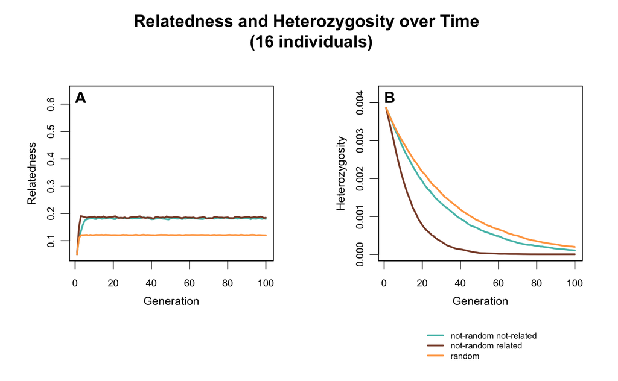

```r
#inset: Pushes it down below the plot
#when running it with 1000 individuals change to lty    = c(1, 1, 2)

text(x = par("usr")[1], y = par("usr")[4], labels = "B", font = 2, cex = 1.1, adj = c(-0.5, 1.5))
```

```r
#par("usr") gives the plot coordinates (so top left corner of the graph - 1 & 4), then labels = ... gives the plot a label, and then make it bold and larger, and adj places the label correctly
```

And a last plot where one can see the median and 25/75% quartiles of the data

```r
par(mfrow = c(1, 2)) #To have 2 plots shown at once
par(mfrow = c(1, 2), oma = c(2, 0, 1, 0))  # oma = outer margin area (bottom, left, top, right), leaves space for a title and some space at the bottom to add a legend outside of the plots.

par(mgp = c(1.8, 0.7, 0)) #This is to decrease the distance of the axis labels to the axis.

par(cex.lab = 0.8, cex.axis = 0.7, cex.main = 1) #this helps me rescaling the size of the labels

#Compute median & quartiles (25 and 75 %)
#the 1 means i want to apply the functions over the rows of my table and ignoring NA values (na.rm = TRUE)
#first for the heterozygosity values
het_med_nrnr <- apply(het_matrix_nrnr, 1, median, na.rm = TRUE)
het_p25_nrnr <- apply(het_matrix_nrnr, 1, function(x) quantile(x, 0.25, na.rm = TRUE))
het_p75_nrnr <- apply(het_matrix_nrnr, 1, function(x) quantile(x, 0.75, na.rm = TRUE))

het_med_nrr  <- apply(het_matrix_nrr,  1, median, na.rm = TRUE)
het_p25_nrr  <- apply(het_matrix_nrr,  1, function(x) quantile(x, 0.25, na.rm = TRUE))
het_p75_nrr  <- apply(het_matrix_nrr,  1, function(x) quantile(x, 0.75, na.rm = TRUE))

het_med_r    <- apply(het_matrix_r,    1, median, na.rm = TRUE)
het_p25_r    <- apply(het_matrix_r,    1, function(x) quantile(x, 0.25, na.rm = TRUE))
het_p75_r    <- apply(het_matrix_r,    1, function(x) quantile(x, 0.75, na.rm = TRUE))

#And now for relatedness values
rel_med_nrnr <- apply(rel_matrix_nrnr, 1, median, na.rm = TRUE)
rel_p25_nrnr <- apply(rel_matrix_nrnr, 1, function(x) quantile(x, 0.25, na.rm = TRUE))
rel_p75_nrnr <- apply(rel_matrix_nrnr, 1, function(x) quantile(x, 0.75, na.rm = TRUE))

rel_med_nrr  <- apply(rel_matrix_nrr,  1, median, na.rm = TRUE)
rel_p25_nrr  <- apply(rel_matrix_nrr,  1, function(x) quantile(x, 0.25, na.rm = TRUE))
rel_p75_nrr  <- apply(rel_matrix_nrr,  1, function(x) quantile(x, 0.75, na.rm = TRUE))

rel_med_r    <- apply(rel_matrix_r,    1, median, na.rm = TRUE)
rel_p25_r    <- apply(rel_matrix_r,    1, function(x) quantile(x, 0.25, na.rm = TRUE))
rel_p75_r    <- apply(rel_matrix_r,    1, function(x) quantile(x, 0.75, na.rm = TRUE))

# Create a vector for the x-values (generations) - this will be used for the x axis of the plot.
x_vals <- 1:100


#Make the plot for the rel values
#define max and min values
max_rel <- max(rel_matrix_nrnr, rel_matrix_nrr, rel_matrix_r)
min_rel <- min(rel_matrix_nrnr, rel_matrix_nrr, rel_matrix_r)

plot(x_vals, rel_med_nrnr, type = "n",
     xlab = "Generation", ylab = "Relatedness",
     ylim = c(min_rel, max_rel)
)

#Draw median (solid line) and quartiles (dashed lines)
# Model: non-random non-related
#when running with 1000 individuals, change size of the blue, dashed lines (lwd = 2), to make them visible behind the orange ones.
lines(x_vals, rel_med_nrnr, col = "#54BFB7FF", lwd = 2.5, lty = 1) #lwd is line width, lty is line type
```

```r
lines(x_vals, rel_p25_nrnr, col = "#54BFB7FF", lwd = 1.5, lty = 3)
lines(x_vals, rel_p75_nrnr, col = "#54BFB7FF", lwd = 1.5, lty = 3)
```

```r
# Model: non-random related
lines(x_vals, rel_med_nrr, col = "#894B33FF", lwd = 2.5, lty = 1)
lines(x_vals, rel_p25_nrr, col = "#894B33FF", lwd = 1.5, lty = 3)
```

```r
lines(x_vals, rel_p75_nrr, col = "#894B33FF", lwd = 1.5, lty = 3)

# Model: random
lines(x_vals, rel_med_r, col = "tan1", lwd = 2.5, lty = 1) #change lty to 4 when running it with 1000 individuals
```

```r
lines(x_vals, rel_p25_r, col = "tan1", lwd = 1.5, lty = 3)
lines(x_vals, rel_p75_r, col = "tan1", lwd = 1.5, lty = 3)
```

```r
text(x = par("usr")[1], y = par("usr")[4], labels = "A", font = 2, cex = 1.1, adj = c(-0.5, 1.5))
#par("usr") gives the plot coordinates (so top left corner of the graph - 1 & 4), then labels = ... gives the plot a label, and then make it bold and larger, and adj places the label correctly

#ANd exactly the same for the het values
#define max and min values
max_het <- max(het_matrix_nrnr, het_matrix_nrr, het_matrix_r)
min_het <- min(het_matrix_nrnr, het_matrix_nrr, het_matrix_r)

#Make a plot with the median and the 25/75% as dashed lines

plot(x_vals, het_med_nrnr, type = "n",
     xlab = "Generation", ylab = "Heterozygosity",
     ylim = c(min_het, max_het + 0.0003) #add 0.0003 to y, such that the "B" is not above the data
)
```

```r
#For het values
# Model: non-random non-related
#when running with 1000 individuals, change size of the blue, dashed lines (lwd = 2), to make them visible behind the orange ones.
lines(x_vals, het_med_nrnr, col = "#54BFB7FF", lwd = 2.5, lty = 1) #lwd is line width, lty is line type
lines(x_vals, het_p25_nrnr, col = "#54BFB7FF", lwd = 1.5, lty = 3)
```

```r
lines(x_vals, het_p75_nrnr, col = "#54BFB7FF", lwd = 1.5, lty = 3)

# Model: non-random related
lines(x_vals, het_med_nrr, col = "#894B33FF", lwd = 2.5, lty = 1)
```

```r
lines(x_vals, het_p25_nrr, col = "#894B33FF", lwd = 1.5, lty = 3)
lines(x_vals, het_p75_nrr, col = "#894B33FF", lwd = 1.5, lty = 3)
```

```r
# Model: random
#When running the code with 1000 individuals, change lty to 4 (not 1), to visualize the blue line behind it.
lines(x_vals, het_med_r, col = "tan1", lwd = 2, lty = 1)
lines(x_vals, het_p25_r, col = "tan1", lwd = 1.5, lty = 3)
```

```r
lines(x_vals, het_p75_r, col = "tan1", lwd = 1.5, lty = 3)

#Add a shared main
mtext("Relatedness and Heterozygosity over Time \n (median & 25/75% - 16 individuals)", side = 3, line = -2, outer = TRUE, cex = 1.2, font = 2) #creates a shared title - change number of individuals!
```

```r
#mtext("(median & 25/75% - 1000 individuals)", side = 3, line = -2, outer = TRUE, cex = 1.2, font = 2) #creates a shared title - change number of individuals!
#font.main = 2 makes the main bold

#Add the legend
par(xpd = NA) #Allows drawing outside of the plot - this is for the legend
legend("bottom", inset = c(0, -0.6), horiz = FALSE, ncol     = 3,
  legend = c("nrnr median", "nrnr 25/75%", "nrr median", "nrr 25/75%", "r median","r 25/75%"),
       col    = c("#54BFB7FF", "#54BFB7FF",
                  "#894B33FF", "#894B33FF",
                  "tan1",       "tan1"),
       lty    = c(1, 2, 1, 2, 1, 2), #change fifth digit to 4 (not 1) when running with 1000 individuals
       lwd    = c(2.5, 1.5, 2.5, 1.5, 2.5, 1.5),
      bty = "n", cex = 0.6)
```

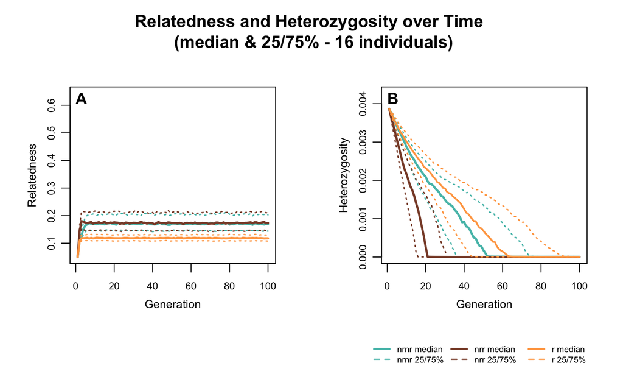

```r
#inset: Pushes it down below the plot

text(x = par("usr")[1], y = par("usr")[4], labels = "B", font = 2, cex = 1.1, adj = c(-0.5, 1.5))
```

```r
#par("usr") gives the plot coordinates (so top left corner of the graph - 1 & 4), then labels = ... gives the plot a label, and then make it bold and larger, and adj places the label correctly
```